# Relatório do LAB1

2025-05-03

Questão 1 - Diferença entre as mensalidades médias e medianas dos cursos de Ciência da Computação nas regiões Nordeste e Sudeste

Justificativa: A diferença pode ocorrer por diversos motivos, os que acredito serem os principais são: bonÇus regionais, alta concentração populacional e grande concentração de centros referências na área na região sudeste, acredito que é uma diferença relevante já que são mais de 100 pontos em média.

Justificativa para as métricas e estatísticas:

Métrica escolhida: O total de bolsas de cada tipo (integral e parcial) foi somado para calcular o número total de bolsas oferecidas por cada curso. A soma das bolsas de “cotas” e “ampla” foi considerada para fornecer uma visão mais abrangente de como os cursos estão distribuídos em termos de apoio financeiro.

Por que isso?: O total de bolsas é a métrica mais direta para comparar a quantidade de apoio financeiro que cada curso oferece aos alunos, seja de cotas, seja ampla. Isso permite identificar quais cursos têm mais oportunidades de bolsas de estudo, o que pode ser importante para alunos que buscam essas oportunidades.

Visualização escolhida:

Gráfico de barras (horizontal): O gráfico de barras horizontais foi escolhido porque facilita a leitura de nomes longos (como os de cursos ou universidades), tornando a interpretação mais clara. Além disso, ele organiza as informações de forma descendente, facilitando a identificação dos cursos com mais bolsas.

Mensalidades Médias e Medianadas nas Regiões Nordeste (NE) e Sudeste (SE)

| Regiao | Media | Mediana |
| --- | --- | --- |
| Nordeste | 712.7342 | 742.8 |
| Sudeste | 899.0594 | 779.0 |

Questão 2 - Top 10 cursos com maior valor de mensalidade pelo total de bolsas

Justificativa: Sim, claramente os cursos com maior mensalidade apresentam pouquissimas vagas, algo que é de se imaginar, vistop que cursos com altos custos universitáios serão menos disponibilziados pelos grandes centros visando uma maior arrecadação de recursos.

Top 10 Cursos Mais Caros em Relação à Média de Mensalidade por Bolsa

| nome | media_mensalidade | total_bolsas | mensalidade_por_bolsa |
| --- | --- | --- | --- |
| Medicina | 7168.342 | 4 | 1792.0854 |
| Odontologia | 2324.165 | 3 | 774.7217 |
| Medicina Veterinária | 1913.436 | 3 | 637.8121 |
| Engenharia de Materiais | 1858.363 | 4 | 464.5908 |
| Arquitetura e Urbanismo | 1277.016 | 3 | 425.6721 |
| Engenharia Mecânica | 1211.362 | 3 | 403.7872 |
| Design de Moda - Modelagem | 1550.000 | 4 | 387.5000 |
| Design | 1142.070 | 3 | 380.6902 |
| Engenharia Civil | 1135.088 | 3 | 378.3626 |
| Fisioterapia | 1120.109 | 3 | 373.3698 |

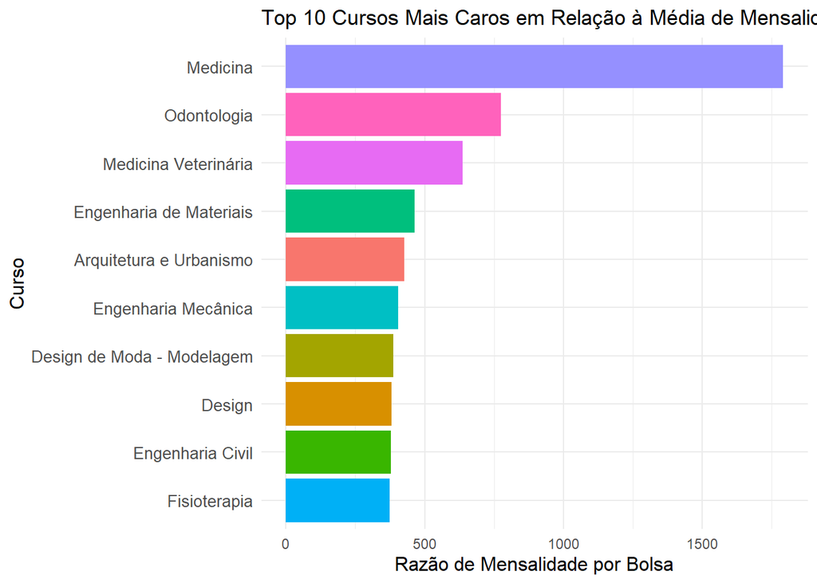

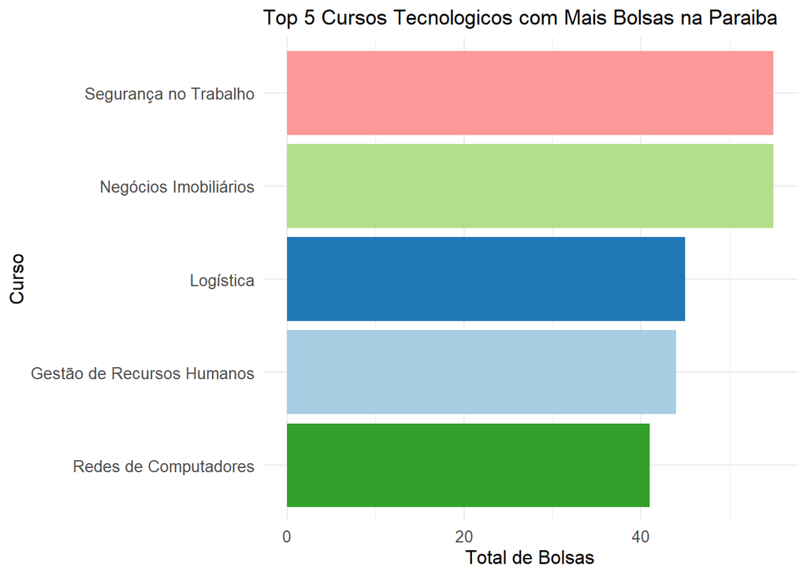

Questão 4 - Percentual de Bolsas por Modalidade em Cursos de Ciência da Computação, Engenharia da Computação e Sistemas de Informação

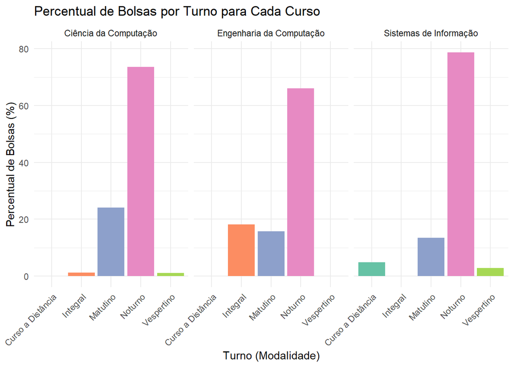